# Homophily and Terrorism

Andreas Haas

23rd of December 2021

## 1. Theory and Hypotheses

Terrorism is considered by many analysts to be one of the major threats to global security. A small number of insurgents can bind a large share of a country's resources that need to be invested to counteract the terrorist threat. Hence, understanding the mechanisms that are at play within such organizations is absolutely crucial. Especially the concept of homophily as proposed by McPherson, Smith-Lovin, and Cook (2001) appears to be important to understand the structures within terrorist organizations. This concept describes that people that «alike» tend to gather together and form rather homogenous groups. Particularly amongst terrorist organizations, it can be expected that homophily may also lead to radicalization, indicating that the most violent and the most radical members will form rather homogenous groups. To examine the role of homophily among terror groups, data gathered by the International Center for the Study of Terrorism at Pennsylvania State University regarding the so-called provisional IRA (PIRA) is exploited. The PIRA is considered to be one of the most active and dangerous terrorist organizations in Europe of the 20th century. The PIRA was founded in the year of 1969, at the Beginning of the Northern Irish conflict; a conflict that would last for almost 30 years and would cost almost 4000 lives. Based on the theoretical considerations regarding homophily the following hypothesis H1 is deducted: H1: Violent/Nonviolent members of the PIRA are more likely to form a tie together. Given that the membership to a specific subgroup most likely also affects the probability of forming a tie, the following second hypothesis H2 is stated: H2: Members from the same PIRA brigade are more likely to form a tie together.

## 3. Explorative Analysis

As the Figure 1 shows, there appears to be a certain amount of homophily in terms of whether PIRA members were involved in violent action or not. Similarly, brigade membership also appears to be a determinant of whether actors would form a tie or not. However, a purely visual inspection of these results does not seem sufficient given that overall homophily does not seem to be extremely strong. Moreover, the network as a whole is characterized by one strongly interconnected network and a multitude of small and isolated networks.

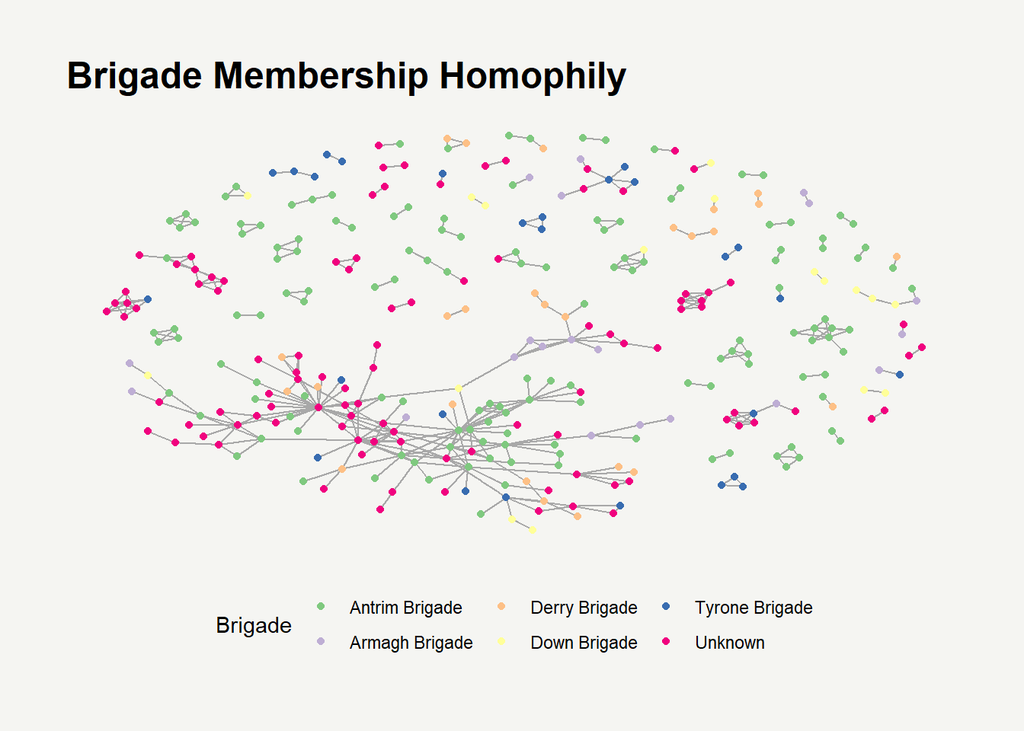

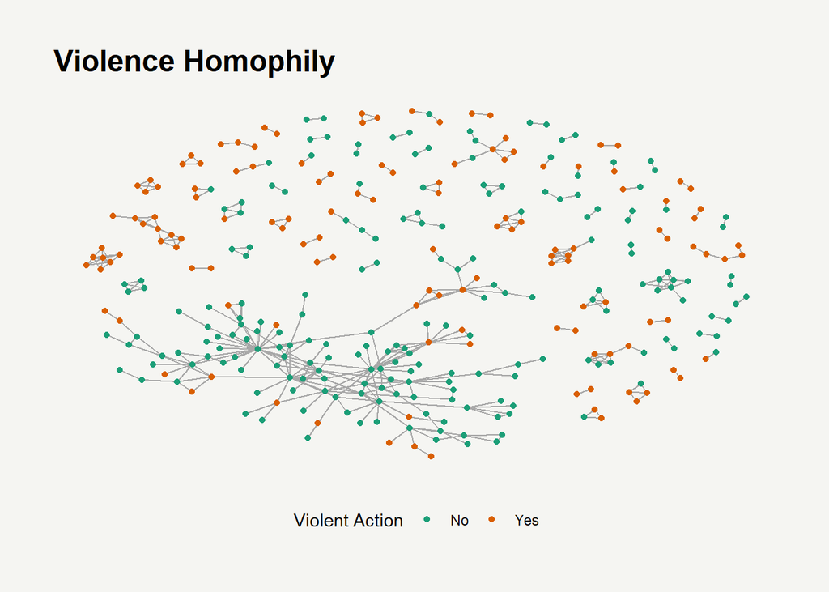

## 4. ERGMs

# 4.1 Model Building

In order to test the underlying hypotheses, three models were estimated in total. The first model represents a baseline model solely including terms considering factorial differences of IRA members forming ties. In order to test the underlying hypotheses regarding homophily, it is essential to focus on terms that help us to investigate whether people that share the same attributes have a greater probability of forming a tie. Hence, nodematch for violent behavior and brigade membership was included as well. In the third and final model, I additionally include terms accounting for transitivity in order to accurately represent the network structure. As can be seen from the final model, there appears to be ample support for the two hypotheses. Unsurprisingly, members of the same brigade are significantly more likely to form a tie with each other (exp(1.4) = 4.1 times more likely). Similarly, terrorists engaging in violence also appear to cluster together (exp(1) = 2.7 times more likely). The same can be found for IRA members not committing any violent actions (exp(0.95) = 2.5 times more likely).

```r
#base model
model_base <- ergm(data ~ edges + nodefactor('brigade') + nodefactor('violent') + nodefactor('non_violent'), verbose = T)

#adding nodematch
model_match <- ergm(data ~ edges + nodefactor('brigade') + nodefactor('violent') + nodefactor('non_violent') + nodematch('brigade') + nodematch('violent') + nodematch('non_violent'), verbose = T)

#estimating final ergm
model <- ergm(data ~ edges + gwesp(0.125, fixed = T) + nodefactor('brigade') + nodefactor('violent') + nodefactor('non_violent') + nodematch('brigade') + nodematch('violent') + nodematch('non_violent'), verbose = T)
```

```r
#summarizing results in table
table <- texreg(list(model_base, model_match, model),
       custom.model.names = c('Baeline', 'Nodematch', 'Final Model'),
       single.row = TRUE,
       caption = 'Comparison of ERG models',
       fontsize = 'footnotesize')
pander(table)
```

[output not shown]

```r
summary(model_base)
```

```
## Call:
## ergm(formula = data ~ edges + nodefactor("brigade") + nodefactor("violent") +
##     nodefactor("non_violent"), verbose = T)
##
## Maximum Likelihood Results:
##
##                                   Estimate Std. Error MCMC % z value Pr(>|z|)
## edges                             -4.93366    0.12230      0 -40.340  < 1e-04
## nodefactor.brigade.Armagh Brigade -0.19360    0.17010      0  -1.138 0.255072
## nodefactor.brigade.Derry Brigade  -0.41498    0.16653      0  -2.492 0.012708
## nodefactor.brigade.Down Brigade   -0.46328    0.20914      0  -2.215 0.026749
## nodefactor.brigade.Tyrone Brigade -0.21762    0.15144      0  -1.437 0.150710
## nodefactor.brigade.Unknown         0.27400    0.07909      0   3.465 0.000531
## nodefactor.violent.1              -0.04886    0.07670      0  -0.637 0.524068
## nodefactor.non_violent.1           0.03798    0.11760      0   0.323 0.746699
##
## edges                             ***
## nodefactor.brigade.Armagh Brigade
## nodefactor.brigade.Derry Brigade  *
## nodefactor.brigade.Down Brigade   *
## nodefactor.brigade.Tyrone Brigade
## nodefactor.brigade.Unknown        ***
## nodefactor.violent.1
## nodefactor.non_violent.1
## ---
## Signif. codes:  0 '***' 0.001 '**' 0.01 '*' 0.05 '.' 0.1 ' ' 1
##
##      Null Deviance: 77093  on 55611  degrees of freedom
##  Residual Deviance:  4753  on 55603  degrees of freedom
##
## AIC: 4769  BIC: 4840  (Smaller is better. MC Std. Err. = 0)
```

```r
summary(model_match)
```

```
## Call:
## ergm(formula = data ~ edges + nodefactor("brigade") + nodefactor("violent") +
##     nodefactor("non_violent") + nodematch("brigade") + nodematch("violent") +
##     nodematch("non_violent"), verbose = T)
##
## Maximum Likelihood Results:
##
##                                   Estimate Std. Error MCMC % z value Pr(>|z|)
## edges                              -8.5304     0.2511      0 -33.975  < 1e-04
## nodefactor.brigade.Armagh Brigade   0.5451     0.1529      0   3.566 0.000363
## nodefactor.brigade.Derry Brigade    0.2971     0.1478      0   2.010 0.044432
## nodefactor.brigade.Down Brigade     0.3151     0.1900      0   1.658 0.097300
## nodefactor.brigade.Tyrone Brigade   0.4235     0.1325      0   3.196 0.001393
## nodefactor.brigade.Unknown          0.2975     0.0623      0   4.775  < 1e-04
## nodefactor.violent.1                0.1230     0.0635      0   1.936 0.052834
## nodefactor.non_violent.1            0.6862     0.1179      0   5.821  < 1e-04
## nodematch.brigade                   1.9363     0.1196      0  16.187  < 1e-04
## nodematch.violent                   1.4114     0.1309      0  10.784  < 1e-04
## nodematch.non_violent               1.2740     0.1907      0   6.682  < 1e-04
##
## edges                             ***
## nodefactor.brigade.Armagh Brigade ***
## nodefactor.brigade.Derry Brigade  *
## nodefactor.brigade.Down Brigade   .
## nodefactor.brigade.Tyrone Brigade **
## nodefactor.brigade.Unknown        ***
## nodefactor.violent.1              .
## nodefactor.non_violent.1          ***
## nodematch.brigade                 ***
## nodematch.violent                 ***
## nodematch.non_violent             ***
## ---
## Signif. codes:  0 '***' 0.001 '**' 0.01 '*' 0.05 '.' 0.1 ' ' 1
##
##      Null Deviance: 77093  on 55611  degrees of freedom
##  Residual Deviance:  4269  on 55600  degrees of freedom
##
## AIC: 4291  BIC: 4389  (Smaller is better. MC Std. Err. = 0)
```

```r
summary(model)
```

```
## Call:
## ergm(formula = data ~ edges + gwesp(0.125, fixed = T) + nodefactor("brigade") +
##     nodefactor("violent") + nodefactor("non_violent") + nodematch("brigade") +
##     nodematch("violent") + nodematch("non_violent"), verbose = T)
##
## Monte Carlo Maximum Likelihood Results:
##
##                                   Estimate Std. Error MCMC % z value Pr(>|z|)
## edges                             -8.53995    0.18636      0 -45.824  < 1e-04
## gwesp.fixed.0.125                  1.95200    0.08618      0  22.651  < 1e-04
## nodefactor.brigade.Armagh Brigade  0.48360    0.10158      0   4.761  < 1e-04
## nodefactor.brigade.Derry Brigade   0.34267    0.09835      0   3.484 0.000494
## nodefactor.brigade.Down Brigade    0.34713    0.13104      0   2.649 0.008072
## nodefactor.brigade.Tyrone Brigade  0.37745    0.08134      0   4.640  < 1e-04
## nodefactor.brigade.Unknown         0.13140    0.03441      0   3.819 0.000134
## nodefactor.violent.1               0.10163    0.03747      0   2.712 0.006679
## nodefactor.non_violent.1           0.49219    0.07134      0   6.899  < 1e-04
## nodematch.brigade                  1.42718    0.09158      0  15.583  < 1e-04
## nodematch.violent                  1.03085    0.10413      0   9.900  < 1e-04
## nodematch.non_violent              0.94768    0.14502      0   6.535  < 1e-04
##
## edges                             ***
## gwesp.fixed.0.125                 ***
## nodefactor.brigade.Armagh Brigade ***
## nodefactor.brigade.Derry Brigade  ***
## nodefactor.brigade.Down Brigade   **
## nodefactor.brigade.Tyrone Brigade ***
## nodefactor.brigade.Unknown        ***
## nodefactor.violent.1              **
## nodefactor.non_violent.1          ***
## nodematch.brigade                 ***
## nodematch.violent                 ***
## nodematch.non_violent             ***
## ---
## Signif. codes:  0 '***' 0.001 '**' 0.01 '*' 0.05 '.' 0.1 ' ' 1
##
##      Null Deviance: 77093  on 55611  degrees of freedom
##  Residual Deviance:  3698  on 55599  degrees of freedom
##
## AIC: 3722  BIC: 3829  (Smaller is better. MC Std. Err. = 0.8485)
```

# 4.2 Model Fit

While the model has converged in the estimation process, it is still crucial to look at the model's fit. By comparing the simulated with the observed network, it is visible that out model appears to have some difficulties in modelling the smaller and isolated networks outside the main network. Hence, the model may not perfectly fit our data. This is further supported by some of the goodness of fit diagnostic plots.

```r
#looking at sample diagnostics
mcmc.diagnostics(model)
```

```
## Sample statistics summary:
##
## Iterations = 68681728:319815680
## Thinning interval = 524288
## Number of chains = 1
## Sample size per chain = 480
##
## 1. Empirical mean and standard deviation for each variable,
##    plus standard error of the mean:
##
##                                     Mean    SD Naive SE Time-series SE
## edges                             4.5312 36.23   1.6535         1.6535
## gwesp.fixed.0.125                 4.2100 37.46   1.7096         1.7096
## nodefactor.brigade.Armagh Brigade 0.5104 10.69   0.4879         0.4879
## nodefactor.brigade.Derry Brigade  1.3021 10.96   0.5005         0.5005
## nodefactor.brigade.Down Brigade   1.0104  8.21   0.3747         0.3747
## nodefactor.brigade.Tyrone Brigade 0.1083 13.99   0.6386         0.6386
## nodefactor.brigade.Unknown        5.9479 47.54   2.1698         2.0577
## nodefactor.violent.1              1.0375 40.99   1.8708         1.8708
## nodefactor.non_violent.1          2.8396 19.58   0.8939         0.8939
## nodematch.brigade                 2.0458 30.66   1.3996         1.3996
## nodematch.violent                 3.8563 32.12   1.4660         1.3229
## nodematch.non_violent             3.6958 33.51   1.5295         1.5295
##
## 2. Quantiles for each variable:
##
##                                     2.5%    25%    50%   75% 97.5%
## edges                             -65.05 -22.25  4.500 31.00 74.00
## gwesp.fixed.0.125                 -68.55 -23.11  5.264 28.23 75.74
## nodefactor.brigade.Armagh Brigade -17.00  -6.00 -1.000  7.00 24.00
## nodefactor.brigade.Derry Brigade  -17.02  -7.00  0.000  8.00 24.00
## nodefactor.brigade.Down Brigade   -14.00  -4.00  0.000  6.00 20.00
## nodefactor.brigade.Tyrone Brigade -25.00  -9.00 -1.000  9.25 27.05
## nodefactor.brigade.Unknown        -83.03 -25.00  8.000 40.25 94.05
## nodefactor.violent.1              -75.00 -30.00  0.000 31.00 81.02
## nodefactor.non_violent.1          -32.02 -11.00  2.000 17.00 42.02
## nodematch.brigade                 -56.02 -21.00  1.000 24.00 60.00
## nodematch.violent                 -55.05 -19.00  3.000 27.00 70.05
## nodematch.non_violent             -60.02 -20.00  4.000 28.00 65.00
##
```

[output cut: 198 more lines]

```
##
## Individual P-values (lower = worse):
##                             edges                 gwesp.fixed.0.125
##                        0.08945536                        0.05364632
## nodefactor.brigade.Armagh Brigade  nodefactor.brigade.Derry Brigade
##                        0.40988504                        0.62503128
##   nodefactor.brigade.Down Brigade nodefactor.brigade.Tyrone Brigade
##                        0.94212611                        0.81884692
##        nodefactor.brigade.Unknown              nodefactor.violent.1
##                        0.22486035                        0.61062314
##          nodefactor.non_violent.1                 nodematch.brigade
##                        0.37309717                        0.08253495
##                 nodematch.violent             nodematch.non_violent
##                        0.06852628                        0.13112434
## Joint P-value (lower = worse):  0.6631529 .
```

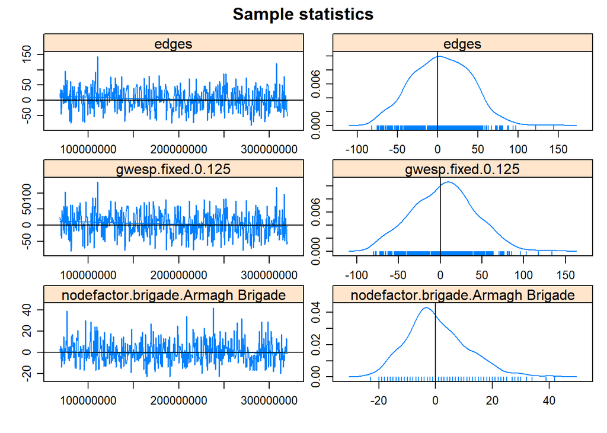

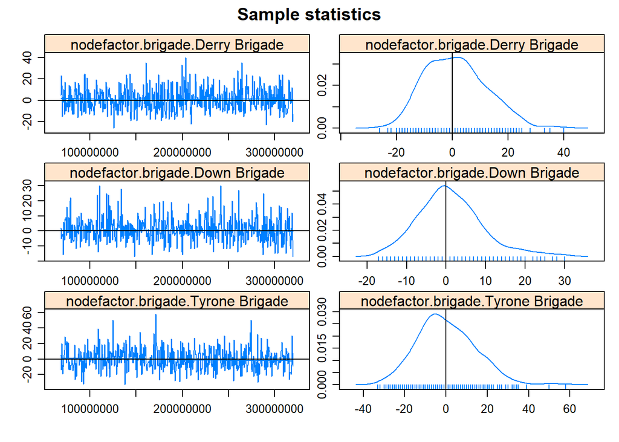

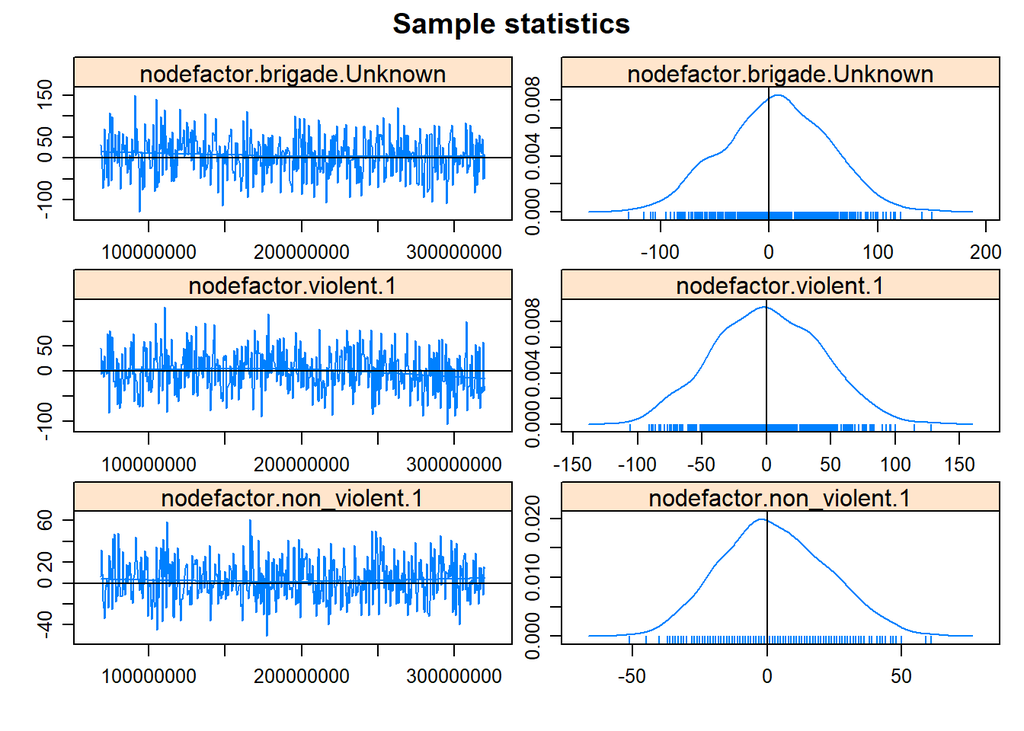

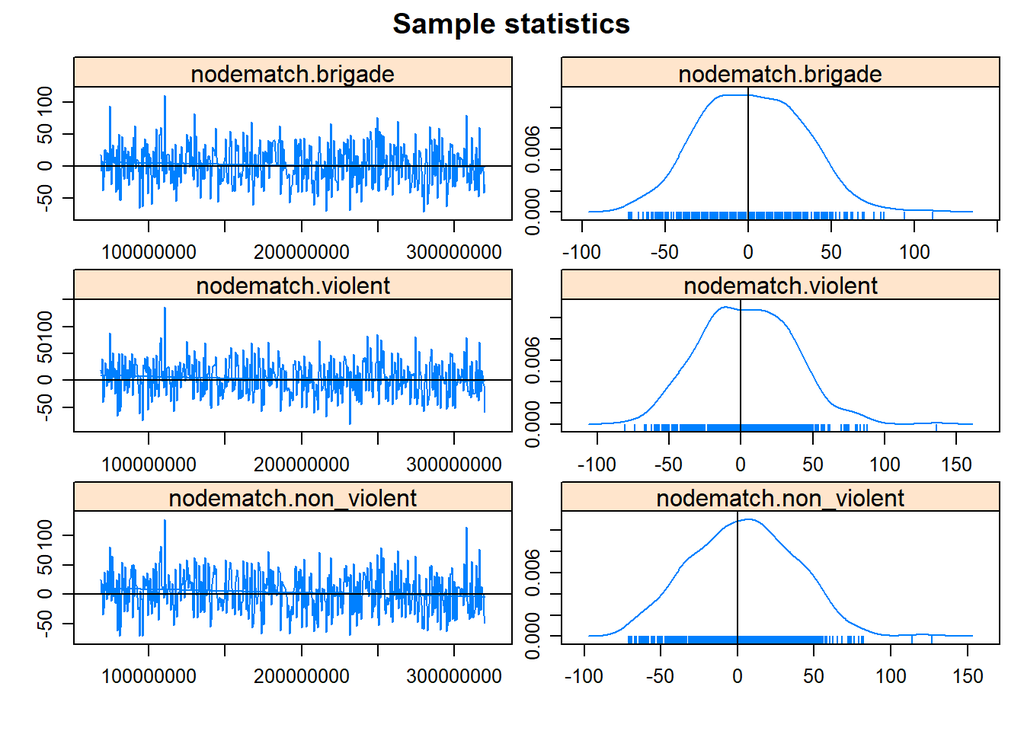

[output not shown]

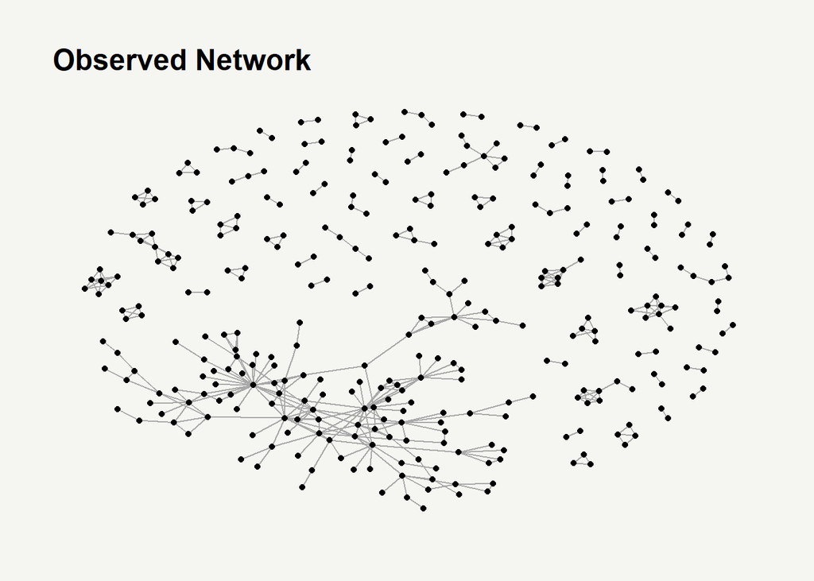

```r
#comparing simulated vs. observed network
sim <- simulate(model)
sim <- as.network(sim)

set.seed(1234)
plot1 <- ggraph(data, layout = "fr") +
  geom_edge_link(edge_colour = "grey66", alpha = 1) +
  geom_node_point() +
  theme_graph() +
  theme(plot.background = element_rect(fill = "#f5f5f2", colour = "#f5f5f2"), legend.background = element_rect(fill = "#f5f5f2", colour = "#f5f5f2"), legend.position = "bottom") +
  labs(title = "Observed Network")
plot1
```

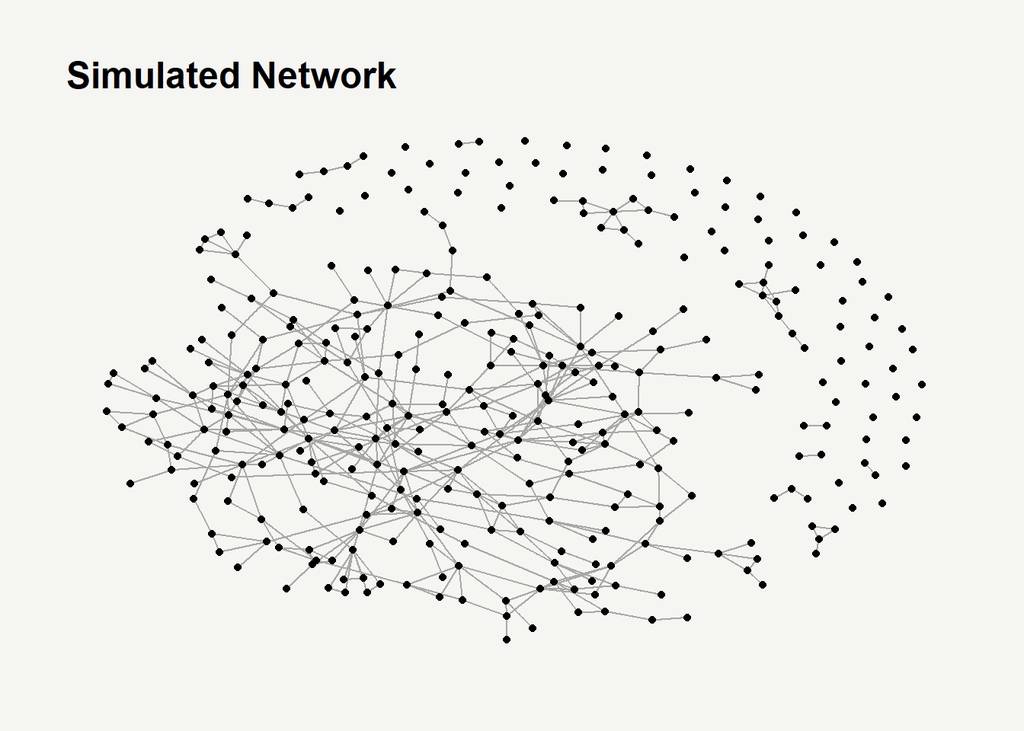

```r
set.seed(1234)
plot2 <- ggraph(sim, layout = "fr") +
  geom_edge_link(edge_colour = "grey66", alpha = 1) +
  geom_node_point() +
  theme_graph() +
  theme(plot.background = element_rect(fill = "#f5f5f2", colour = "#f5f5f2"), legend.background = element_rect(fill = "#f5f5f2", colour = "#f5f5f2"), legend.position = "bottom") +
  labs(title = "Simulated Network")
plot2
```

```r
#goodness of fit
(model2 <- gof(model,  GOF = ~ degree + triadcensus + espartners - model))
```

```
##
## Goodness-of-fit for degree
##
##          obs min  mean max MC p-value
## degree0    0  46 69.31  93       0.00
## degree1  156  35 56.83  88       0.00
## degree2   75  43 62.16  83       0.12
## degree3   39  32 49.27  64       0.12
## degree4   25  25 35.17  52       0.06
## degree5   14  10 24.07  37       0.10
## degree6   10   6 15.50  24       0.26
## degree7    2   2  9.58  18       0.06
## degree8    7   1  5.16  12       0.56
## degree9    1   0  3.17   9       0.46
## degree10   1   0  1.82   6       0.94
## degree11   1   0  0.90   5       1.00
## degree12   0   0  0.50   3       1.00
## degree13   1   0  0.25   2       0.40
## degree14   0   0  0.14   2       1.00
## degree15   0   0  0.08   2       1.00
## degree16   0   0  0.03   1       1.00
## degree17   0   0  0.02   1       1.00
## degree18   1   0  0.01   1       0.02
## degree19   0   0  0.01   1       1.00
## degree20   0   0  0.02   1       1.00
## degree26   1   0  0.00   0       0.00
##
## Goodness-of-fit for triad census
##
##                   obs     min       mean     max MC p-value
## triadcensus.0 6021208 5991147 6012649.11 6040025       0.42
## triadcensus.1  131870  113397  140306.32  161423       0.42
## triadcensus.2    1028     724    1206.67    1579       0.38
## triadcensus.3     178      83     121.90     155       0.00
##
## Goodness-of-fit for edgewise shared partner
##
##      obs min   mean max MC p-value
## esp0 145 108 131.33 154       0.26
## esp1  96 172 242.67 292       0.00
## esp2  91  26  48.97  70       0.00
## esp3  45   1   7.09  17       0.00
## esp4  19   0   0.80   4       0.00
## esp5   9   0   0.11   2       0.00
## esp7   0   0   0.01   1       1.00
##
## Goodness-of-fit for model statistics
##
##                                        obs     min     mean      max MC p-value
## edges                             405.0000 347.000 430.9800 497.0000       0.42
## gwesp.fixed.0.125                 280.3256 213.389 306.4574 375.8456       0.54
## nodefactor.brigade.Armagh Brigade  39.0000  20.000  41.6400  64.0000       0.86
## nodefactor.brigade.Derry Brigade   41.0000  18.000  42.5100  63.0000       0.96
## nodefactor.brigade.Down Brigade    25.0000  11.000  30.1700  49.0000       0.74
## nodefactor.brigade.Tyrone Brigade  51.0000  18.000  50.6300  82.0000       1.00
## nodefactor.brigade.Unknown        318.0000 257.000 313.1700 372.0000       0.78
## nodefactor.violent.1              302.0000 260.000 354.1100 424.0000       0.12
## nodefactor.non_violent.1           88.0000  52.000  90.9200 120.0000       0.88
## nodematch.brigade                 283.0000 240.000 304.5500 360.0000       0.44
## nodematch.violent                 331.0000 280.000 354.9900 424.0000       0.48
## nodematch.non_violent             361.0000 322.000 388.6600 441.0000       0.34
```

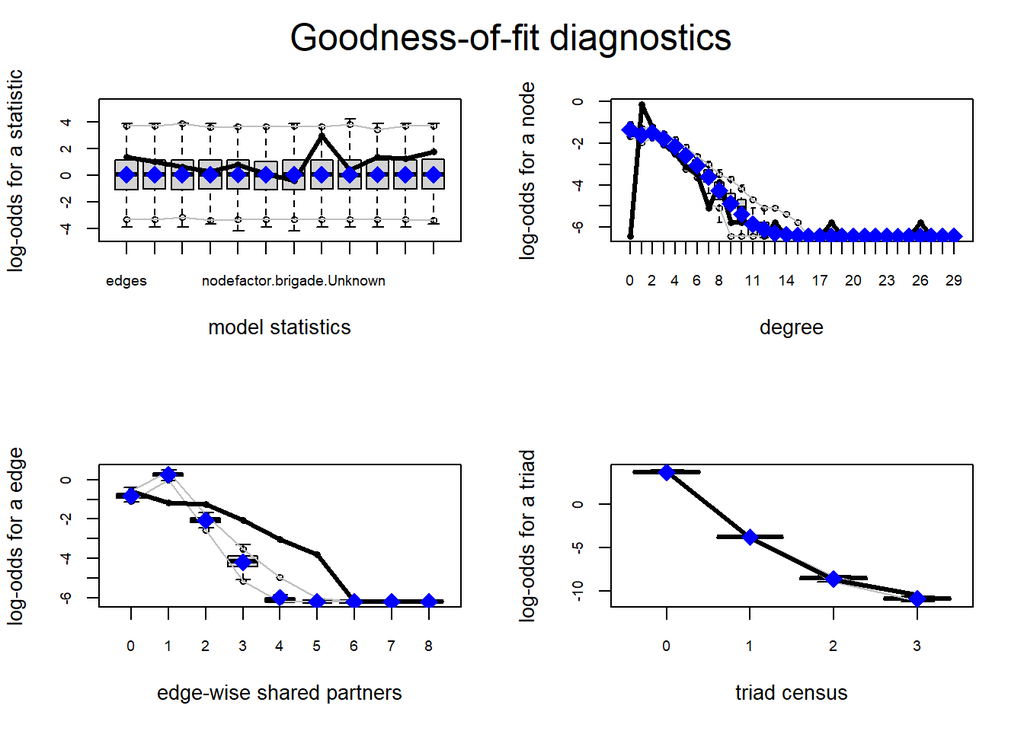

```r
par(mfrow=c(2,2))
plot(model2, plotlogodds=T) # Add the argument "plotlogodds=T" here to rescale
```

```r
par(mfrow=c(1,1))
```

## 5. Conclusion

As could be shown, violent behavior appears to be an important predictor of ties formed within terrorist groups (apart from membership in the same terror "cell"). Hence, violence may indeed lead to more homogenous and violent groups within terror organizations. However, it is not possible to conclude whether it was violence per se that lead to a tie or whether people formed into groups based on other characteristics that could have fostered violent behavior.